# Project: Investigate Internet Movie Database

- Introduction
- Data Wrangling
- Exploratory Data Analysis
- Conclusions

## Introduction

I have selected data set that contains information about 10,000 movies collected from The Movie Database (TMDb), including user ratings and revenue.

Here are the questions that I plan to explore

1. Are big budget movies more popular than lower budget movies?
2. Do big budget films generate more revenue?
3. Are movies with longer runtime more popular?
4. Who are the directors with most numbers of movies?
5. What were most popular genres in each year?
6. How many movies were made in each year?
7. Who were most popular directors each year?
8. Did movies in 1960s had more budgets/adjusted budgets than in 2015?
9. Did movies in 1960s had more revenue/adjusted revenue than in 2015?

```python
import numpy as np
import pandas as pd
import matplotlib.pyplot as plt
import seaborn as sns #make visualitions
%matplotlib inline
```

## Data Wrangling

### General Properties

```python
df = pd.read_csv('tmdb-movies.csv')
df.head()
```

|  | id | imdb_id | popularity | budget | revenue | original_title | cast | homepage | director | tagline | ... | overview | runtime | genres | production_companies | release_date | vote_count | vote_average | release_year | budget_adj | revenue_adj |
| --- | --- | --- | --- | --- | --- | --- | --- | --- | --- | --- | --- | --- | --- | --- | --- | --- | --- | --- | --- | --- | --- |
| 0 | 135397 | tt0369610 | 32.985763 | 150000000 | 1513528810 | Jurassic World | Chris Pratt\|Bryce Dallas Howard\|Irrfan Khan\|Vi... | http://www.jurassicworld.com/ | Colin Trevorrow | The park is open. | ... | Twenty-two years after the events of Jurassic ... | 124 | Action\|Adventure\|Science Fiction\|Thriller | Universal Studios\|Amblin Entertainment\|Legenda... | 6/9/15 | 5562 | 6.5 | 2015 | 1.379999e+08 | 1.392446e+09 |
| 1 | 76341 | tt1392190 | 28.419936 | 150000000 | 378436354 | Mad Max: Fury Road | Tom Hardy\|Charlize Theron\|Hugh Keays-Byrne\|Nic... | http://www.madmaxmovie.com/ | George Miller | What a Lovely Day. | ... | An apocalyptic story set in the furthest reach... | 120 | Action\|Adventure\|Science Fiction\|Thriller | Village Roadshow Pictures\|Kennedy Miller Produ... | 5/13/15 | 6185 | 7.1 | 2015 | 1.379999e+08 | 3.481613e+08 |
| 2 | 262500 | tt2908446 | 13.112507 | 110000000 | 295238201 | Insurgent | Shailene Woodley\|Theo James\|Kate Winslet\|Ansel... | http://www.thedivergentseries.movie/#insurgent | Robert Schwentke | One Choice Can Destroy You | ... | Beatrice Prior must confront her inner demons ... | 119 | Adventure\|Science Fiction\|Thriller | Summit Entertainment\|Mandeville Films\|Red Wago... | 3/18/15 | 2480 | 6.3 | 2015 | 1.012000e+08 | 2.716190e+08 |
| 3 | 140607 | tt2488496 | 11.173104 | 200000000 | 2068178225 | Star Wars: The Force Awakens | Harrison Ford\|Mark Hamill\|Carrie Fisher\|Adam D... | http://www.starwars.com/films/star-wars-episod... | J.J. Abrams | Every generation has a story. | ... | Thirty years after defeating the Galactic Empi... | 136 | Action\|Adventure\|Science Fiction\|Fantasy | Lucasfilm\|Truenorth Productions\|Bad Robot | 12/15/15 | 5292 | 7.5 | 2015 | 1.839999e+08 | 1.902723e+09 |
| 4 | 168259 | tt2820852 | 9.335014 | 190000000 | 1506249360 | Furious 7 | Vin Diesel\|Paul Walker\|Jason Statham\|Michelle ... | http://www.furious7.com/ | James Wan | Vengeance Hits Home | ... | Deckard Shaw seeks revenge against Dominic Tor... | 137 | Action\|Crime\|Thriller | Universal Pictures\|Original Film\|Media Rights ... | 4/1/15 | 2947 | 7.3 | 2015 | 1.747999e+08 | 1.385749e+09 |

5 rows × 21 columns

```python
# df.shape | Number of rows and columns
df.shape
```

```
(10866, 21)
```

```python
# df.describe() | Summary statistics for numerical columns
df.describe()
```

|  | id | popularity | budget | revenue | runtime | vote_count | vote_average | release_year | budget_adj | revenue_adj |
| --- | --- | --- | --- | --- | --- | --- | --- | --- | --- | --- |
| count | 10866.000000 | 10866.000000 | 1.086600e+04 | 1.086600e+04 | 10866.000000 | 10866.000000 | 10866.000000 | 10866.000000 | 1.086600e+04 | 1.086600e+04 |
| mean | 66064.177434 | 0.646441 | 1.462570e+07 | 3.982332e+07 | 102.070863 | 217.389748 | 5.974922 | 2001.322658 | 1.755104e+07 | 5.136436e+07 |
| std | 92130.136561 | 1.000185 | 3.091321e+07 | 1.170035e+08 | 31.381405 | 575.619058 | 0.935142 | 12.812941 | 3.430616e+07 | 1.446325e+08 |
| min | 5.000000 | 0.000065 | 0.000000e+00 | 0.000000e+00 | 0.000000 | 10.000000 | 1.500000 | 1960.000000 | 0.000000e+00 | 0.000000e+00 |
| 25% | 10596.250000 | 0.207583 | 0.000000e+00 | 0.000000e+00 | 90.000000 | 17.000000 | 5.400000 | 1995.000000 | 0.000000e+00 | 0.000000e+00 |
| 50% | 20669.000000 | 0.383856 | 0.000000e+00 | 0.000000e+00 | 99.000000 | 38.000000 | 6.000000 | 2006.000000 | 0.000000e+00 | 0.000000e+00 |
| 75% | 75610.000000 | 0.713817 | 1.500000e+07 | 2.400000e+07 | 111.000000 | 145.750000 | 6.600000 | 2011.000000 | 2.085325e+07 | 3.369710e+07 |
| max | 417859.000000 | 32.985763 | 4.250000e+08 | 2.781506e+09 | 900.000000 | 9767.000000 | 9.200000 | 2015.000000 | 4.250000e+08 | 2.827124e+09 |

# Data Cleansing

Based on the output of head and describe command, I feel following columns are not required for further analysis.

| Not required Column | Reason |
| --- | --- |
| id | Number meaningful only to IMDB |
| imdb_id | Number meaningful only to IMDB |
| original_title | Textual information, cannot be meaningfully analyzed |
| cast | Do not have data about each cast member e.g. their rating, popularity, net worth etc. |
| homepage | Textual information, cannot be meaningfully analyzed |
| tagline | Textual information, cannot be meaningfully analyzed |
| overview | Textual information, cannot be meaningfully analyzed |
| keywords | Textual information, cannot be meaningfully analyzed |

Hence these columns will be removed from data frame

```python
# Remove not needed columns
df.drop(["id", "imdb_id", "original_title", "cast", "homepage", "tagline", "overview", "keywords"], axis=1, inplace=True)
df.head(5);
```

```python
# df.info() | Index, Datatype and Memory information
df.info()
```

```
<class 'pandas.core.frame.DataFrame'>
RangeIndex: 10866 entries, 0 to 10865
Data columns (total 13 columns):
popularity              10866 non-null float64
budget                  10866 non-null int64
revenue                 10866 non-null int64
director                10822 non-null object
runtime                 10866 non-null int64
genres                  10843 non-null object
production_companies    9836 non-null object
release_date            10866 non-null object
vote_count              10866 non-null int64
vote_average            10866 non-null float64
release_year            10866 non-null int64
budget_adj              10866 non-null float64
revenue_adj             10866 non-null float64
dtypes: float64(4), int64(5), object(4)
memory usage: 1.1+ MB
```

## Plotting histograms to get a quick glance at data

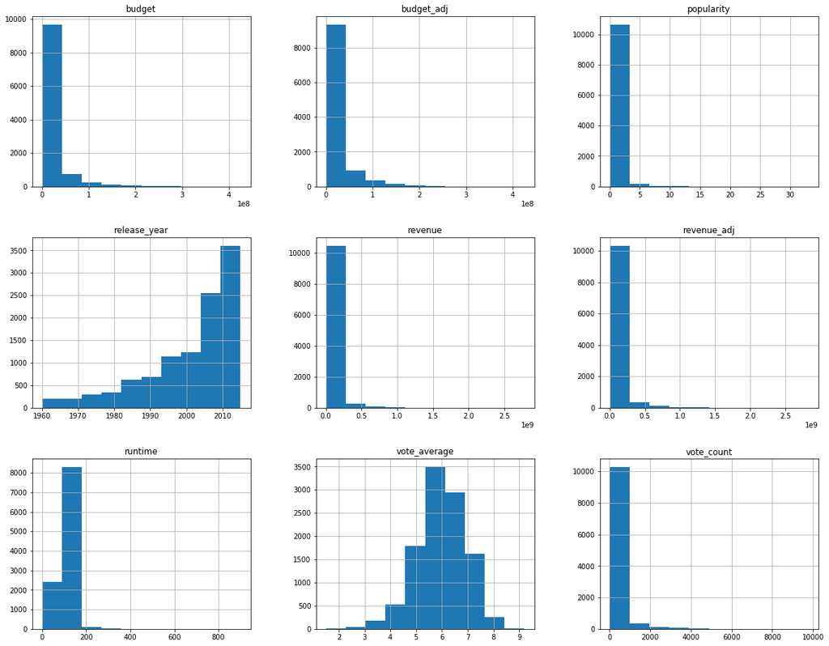

```python
df.hist(figsize=(20,16));
```

### Research Question 1: Are big budget films more popular?

### Research Question 2: Do big budget films generate more revenue?

### Research Question 3: Are movies with longer runtime more popular?

Plotting popularity vs. budget values and revenue vs. budget to answer these questions

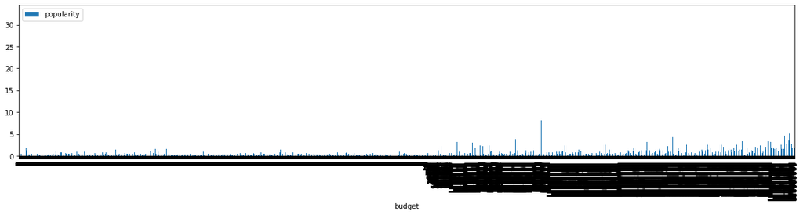

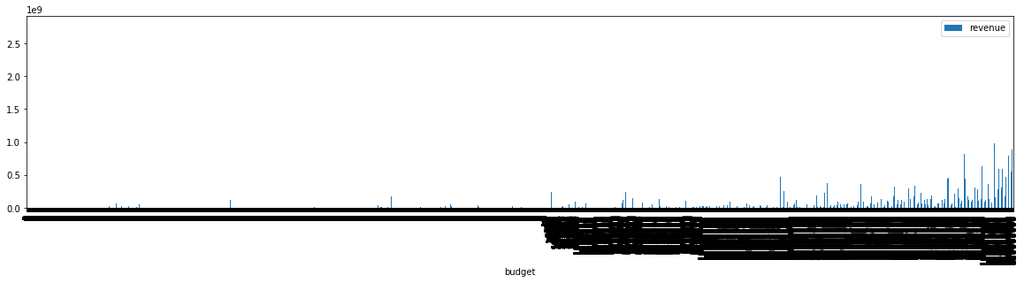

```python
# Sort entire data frame by budget.
df.sort_values('budget', inplace=True)

# Plot Popularity column against budget column on X Axis
df.plot.bar('budget','popularity', figsize=(20,4));

# Plot Revenue column against budget column on X Axis
df.plot.bar('budget','revenue', figsize=(20,4));
```

- From above graphs, although we can see that popularity and revenue values are higher as we go to the right side of graph, it is not easy to conclude that fact.
- It is more easier to see that co-relation when mean popularity values for each bucket are plotted.
- Hence I wrote a generic function named plot_mean_values()
  - To take x-axis and y-axis columns as parameter
  - X Axis column name defaults to 'budget' since it is used in many graphs
  - Caller can pass its own bins and bin labels.
    - Default values for these parameters are used when budget is on X-Axis
  - X-axis column is divided into bins using `cut` function so that each row has a bin label.
  - Data frame is then grouped by these labels using `groupby` function.
  - Mean value of Y-Axis column in each bin calculated and plotted against X-Axis column

```python
def plot_mean_values(y_axis_column, x_axis_column = 'budget', bins = None, bin_labels = None):

    # Create bins if not passed by caller
    if bins is None:
        bins = [0, 1e6, 5e6, 10e6, 25e6, 50e6, 100e6, 150e6, 200e6]

    # Create labels for bins if not passed by caller
    if bin_labels is None:
        bin_labels = ['0-1M', '1-5M', '5-10M', '10-25M', '25-50M', '50-100M', '100-150M', '150-200M']

    # Use Pandas cut command to divide x_axis_column values in bins
    # and create new column named x_axis_column in data frame
    # Each row in data frame will have a column x_axis_column with one of values in bin_labels
    bin_column_name = x_axis_column + '_bins'
    df[bin_column_name] = pd.cut(df[x_axis_column], bins, labels=bin_labels)

    # Define two arrays
    # bins_values will hold 8 possible values from bin_labels
    bins_values = []
    # mean_values will hold average popularity values for each bucket
    mean_values = []

    # groupby function groups all rows together that have same values in budget_bins
    # E.g. all movies with revenue between 5-10M will be in group titled '5-10M'
    bin_groups = df.groupby(bin_column_name)

    # Iterate over groups
    # There are 8 groups here.
    # Each one of 10k+ rows are in one of 8 groups
    for group_title, group in bin_groups:

        # Store groups title in budget_bins_values array
        bins_values.append(group_title)

        # From correspoding group, extract the column, calculate mean and store in mean_values array
        mean_values.append(group[y_axis_column].mean())

    # Create Python object from two arrays
    y_axis_column_name = "{0} mean".format(y_axis_column)
    obj_for_df = { x_axis_column : bins_values,
                   y_axis_column_name : mean_values }

    # Create a new dataframe from python object
    popularity_df = pd.DataFrame(obj_for_df)

    # Plot graph of budget bins with
    graph_title = '{0} vs {1}'.format(y_axis_column, x_axis_column)
    popularity_df.plot(x_axis_column, y_axis_column_name, figsize=(15,4), title=graph_title)
```

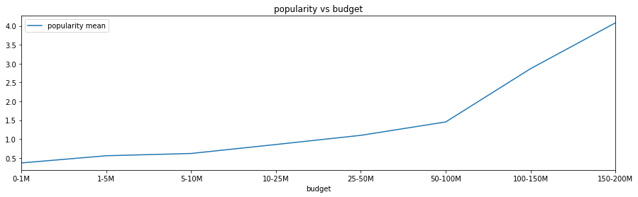

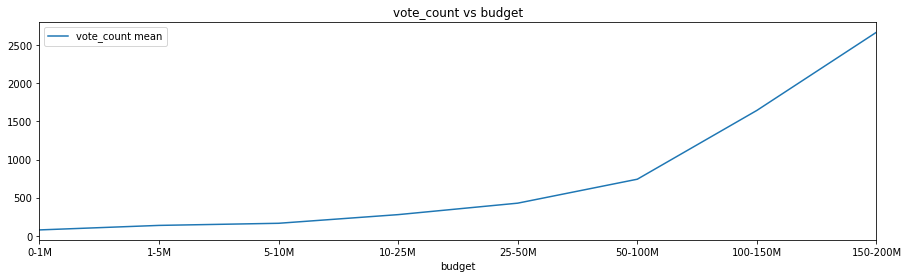

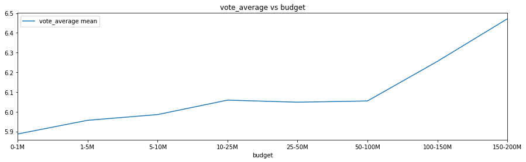

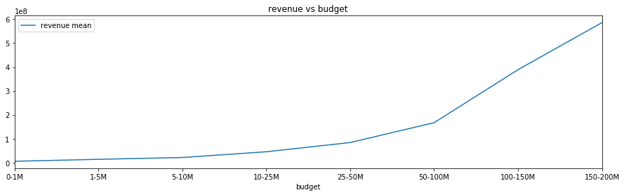

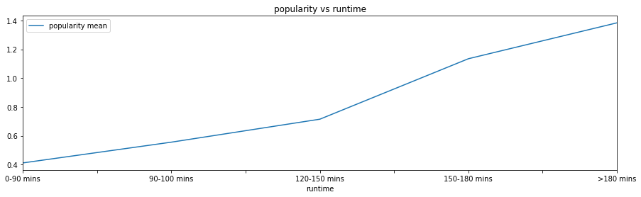

```python
plot_mean_values('popularity')
plot_mean_values('vote_count')
plot_mean_values('vote_average')
plot_mean_values('revenue')
plot_mean_values('popularity', 'runtime',
                 [0, 90, 100, 120, 150, 180],
                 ['0-90 mins', '90-100 mins', '120-150 mins', '150-180 mins', '>180 mins'])
```

### Conclusion

1. Popularity, vote count and vote average goes up as budget increases.
2. Revenue increases as budget goes up
3. Longer running films are more popular.

### Research Question 4 Who are the directors with most numbers of movies?

```python
# Group data frame by directory column
director_groups = df.groupby(df['director'])

# Count rows in each group.
# popularity column is randomly selected here otherwise we have to deal with multiple columns in the series.
dir_count_series = director_groups.count()['popularity'].sort_values(ascending=False)

pd.options.display.max_rows = 120

# From the series, find directors that have directed 10 or more films
dir_count_series[lambda x: x >= 10]
```

```
director
Woody Allen                      45
Clint Eastwood                   34
Steven Spielberg                 29
Martin Scorsese                  29
Ridley Scott                     23
Steven Soderbergh                22
Ron Howard                       22
Joel Schumacher                  21
Brian De Palma                   20
Wes Craven                       19
Barry Levinson                   19
Tim Burton                       19
Mike Nichols                     18
David Cronenberg                 18
John Carpenter                   18
Rob Reiner                       18
Renny Harlin                     17
Sidney Lumet                     17
Oliver Stone                     17
Francis Ford Coppola             17
Spike Lee                        17
Stephen Frears                   17
Robert Zemeckis                  17
Tyler Perry                      17
Walter Hill                      17
Norman Jewison                   17
Peter Hyams                      17
Stephen Herek                    16
John Landis                      16
Uwe Boll                         16
Roman Polanski                   16
Tony Scott                       16
Richard Linklater                16
Blake Edwards                    16
Richard Donner                   16
Neil Jordan                      15
Gus Van Sant                     15
Robert Altman                    15
Ivan Reitman                     15
```

[output cut: 67 more lines]

```
John Boorman                     10
Paul W.S. Anderson               10
Ken Loach                        10
Don Siegel                       10
Donald Petrie                    10
Rob Cohen                        10
Antoine Fuqua                    10
Steve Rash                       10
Guy Hamilton                     10
Jon Turteltaub                   10
Harold Ramis                     10
Mike Leigh                       10
John McTiernan                   10
Joel Coen                        10
Name: popularity, dtype: int64
```

Above operation is equivalent to this SQL.

```
select director, count(*)
from movies_db
group by director
order by count(*) desc
having count(*) >= 10
```

### Research Question 5 What were most popular genres in each year?

```python
pop_genres_by_year_df = df.groupby(['genres', 'release_year'], as_index=False)['popularity'].mean()

pop_genres_by_year_df = pop_genres_by_year_df.sort_values('popularity',ascending = False).groupby('release_year').head(1)
print(df2.sort_values('release_year').to_string(index=False))
```

[output not shown]

### Research Question 6 How many movies were made in each year?

```
    release_year  count
0           1960     32
1           1961     31
2           1962     32
3           1963     34
4           1964     42
5           1965     35
6           1966     46
7           1967     40
8           1968     39
9           1969     31
10          1970     41
11          1971     55
12          1972     40
13          1973     55
```

[output cut: 42 more lines]

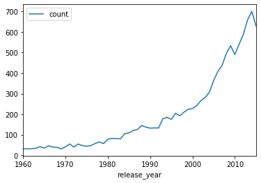

```python
movies_by_year_df1 = df.groupby('release_year', as_index=False).count()

# Get Required Columns
movies_by_year_df1 = movies_by_year_df1[ ['release_year', 'popularity'] ]

# Rename Columns
movies_by_year_df1.columns = ['release_year', 'count']

print(movies_by_year_df1)
movies_by_year_df1.plot(x='release_year');
```

### Research Question 7 Who were most popular director each year?

```python
pop_director_per_year_df = df.groupby(['director', 'release_year'], as_index=False)['popularity'].mean()

pop_director_per_year_df = pop_director_per_year_df.sort_values('popularity',ascending = False).groupby('release_year').head(1)
pop_director_per_year_df.columns = [ 'director', 'release_year', 'mean_popularity']
print(pop_director_per_year_df.sort_values('release_year').to_string(index=False))
```

```
                                          director  release_year  mean_popularity
                                  Alfred Hitchcock          1960         2.610362
 Clyde Geronimi|Hamilton Luske|Wolfgang Reitherman          1961         2.631987
                                     Terence Young          1962         3.170651
                                     Terence Young          1963         2.508235
                                      Guy Hamilton          1964         3.153791
                                     Terence Young          1965         1.910465
                            Chuck Jones|Ben Washam          1966         1.227582
                               Wolfgang Reitherman          1967         2.550704
                                   Stanley Kubrick          1968         3.309196
                                     Peter R. Hunt          1969         1.778746
                               Wolfgang Reitherman          1970         1.936962
                                   Stanley Kubrick          1971         3.072555
                              Francis Ford Coppola          1972         5.738034
                               Wolfgang Reitherman          1973         2.272486
                              Francis Ford Coppola          1974         2.013175
                                     MiloÅ¡ Forman          1975         3.258151
                                   Martin Scorsese          1976         2.582657
                                      George Lucas          1977        12.037933
                                    Randal Kleiser          1978         1.697618
                                      Ridley Scott          1979         4.935897
                                    Irvin Kershner          1980         5.488441
                                  Steven Spielberg          1981         4.578300
                                      Ridley Scott          1982         4.215642
                                  Richard Marquand          1983         4.828854
                                     James Cameron          1984         4.831966
                                   Robert Zemeckis          1985         6.095293
                                     James Cameron          1986         2.485419
                                    John McTiernan          1987         3.474728
                                    John McTiernan          1988         3.777441
                          Ron Clements|John Musker          1989         4.143585
                                    Paul Verhoeven          1990         2.679627
                          Gary Trousdale|Kirk Wise          1991         3.852269
                                 Quentin Tarantino          1992         4.586426
                                      Harold Ramis          1993         2.571339
                                 Quentin Tarantino          1994         8.093754
                                     David Fincher          1995         4.765359
                                   Roland Emmerich          1996         4.480733
                                  Peter Richardson          1997         6.668990
                                        Peter Weir          1998         4.180540
                                     David Fincher          1999         8.947905
                                      Ridley Scott          2000         4.271452
                                     Peter Jackson          2001         8.575419
                                     Peter Jackson          2002         8.095275
                                     Peter Jackson          2003         7.122455
                                   Alfonso CuarÃ³n          2004         5.827781
                                       Mike Newell          2005         5.939927
                                       Len Wiseman          2006         5.838503
                                    Gore Verbinski          2007         4.965391
                                 Christopher Nolan          2008         8.466668
                                     James Cameron          2009         9.432768
                                 Christopher Nolan          2010         9.363643
                                     Juno John Lee          2011         8.411577
                       MÃ¥ns MÃ¥rlind|BjÃ¶rn Stein          2012         7.031452
                           Chris Buck|Jennifer Lee          2013         6.112766
                                 Christopher Nolan          2014        24.949134
                                   Colin Trevorrow          2015        32.985763
```

### Research Question 8 Did movies in 1960s had more budgets/adjusted budgets than in 2015?

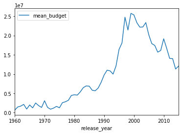

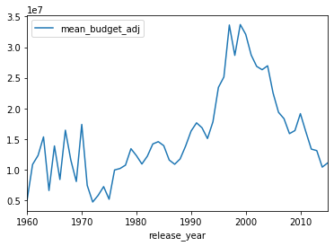

```python
# Average Budget per year
budget_per_year_df = df.groupby('release_year', as_index=False).mean()
budget_per_year_df = budget_per_year_df [ ['release_year', 'budget' ] ]
budget_per_year_df.columns = [ 'release_year', 'mean_budget']

budget_per_year_df.plot(x='release_year')

# Average Budget_adj per year
budget_adj_per_year_df = df.groupby('release_year', as_index=False).mean()
budget_adj_per_year_df = budget_adj_per_year_df [ ['release_year', 'budget_adj' ] ]
budget_adj_per_year_df.columns = [ 'release_year', 'mean_budget_adj']

budget_adj_per_year_df.plot(x='release_year')
```

### Research Question 9 Did movies in 1960s had more revenue/adjusted revenue than in 2015?

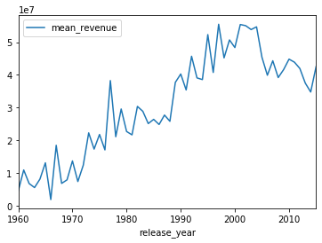

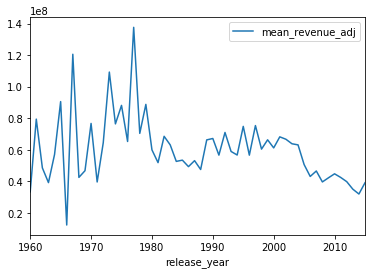

```python
# Average Revenue per year
revenue_per_year_df = df.groupby('release_year', as_index=False).mean()
revenue_per_year_df = revenue_per_year_df [ ['release_year', 'revenue' ] ]
revenue_per_year_df.columns = [ 'release_year', 'mean_revenue']

revenue_per_year_df.plot(x='release_year')

# Average Revenue_adj per year
revenue_adj_per_year_df = df.groupby('release_year', as_index=False).mean()
revenue_adj_per_year_df = revenue_adj_per_year_df [ ['release_year', 'revenue_adj' ] ]
revenue_adj_per_year_df.columns = [ 'release_year', 'mean_revenue_adj']

revenue_adj_per_year_df.plot(x='release_year')
```

#### Conclusion

Looking at revenue values only, it seems that year 2000 again saw big revenue films

- 1960's films had significantly lower revenues
  - Inflation adjusted revenue values paint a completely opposite picture.
- 1960's films actually brought in more revenue than in 2015

```python
from subprocess import call
call(['python', '-m', 'nbconvert', 'Investigate_a_Dataset.ipynb'])
```

```
255
```